# R Notebook

```r
#install.packages("readxl")
dat <- readxl::read_xls("/Users/brittbovbjerg/Desktop/DS202/ds202_lab3-master/GSS.xls")
library(dplyr)
#data cleaning
colnames(dat) <- c('year', "married", "children", "sex","party","relig","happy", "happy_marriage","health")
str(dat)
```

```
## Classes 'tbl_df', 'tbl' and 'data.frame':    64814 obs. of  9 variables:
##  $ year          : num  1972 1972 1972 1972 1972 ...
##  $ married       : chr  "Never married" "Married" "Married" "Married" ...
##  $ children      : chr  "0" "5" "4" "0" ...
##  $ sex           : chr  "Female" "Male" "Female" "Female" ...
##  $ party         : chr  "Ind,near dem" "Not str democrat" "Independent" "Not str democrat" ...
##  $ relig         : chr  "Once a year" "Every week" "Once a month" "Never" ...
##  $ happy         : chr  "Not too happy" "Not too happy" "Pretty happy" "Not too happy" ...
##  $ happy_marriage: chr  "Not applicable" "Not applicable" "Not applicable" "Not applicable" ...
##  $ health        : chr  "Good" "Fair" "Excellent" "Good" ...
```

```r
#list of row values that need to be removed to answer questions
count(dat, 'married')
```

| "married" | n |
| --- | --- |
| married | 64814 |

```r
#need to remove "No answer" = 27 respondents
count(dat, 'children')
```

| "children" | n |
| --- | --- |
| children | 64814 |

```r
#need to remove "Dk na" = 201 respondents
count(dat, "party")
```

| "party" | n |
| --- | --- |
| party | 64814 |

```r
#need to remove "Don't know" =11 and "No answer" = 407 and "Other party" = 1072
count(dat, "relig")
```

| "relig" | n |
| --- | --- |
| relig | 64814 |

```r
#need to remove "Dk,na" = 595
count(dat, "happy")
```

| "happy" | n |
| --- | --- |
| happy | 64814 |

```r
#need to remove "Don't know" = 39, "No answer" = 338, and "Not applicable" = 4383
count(dat, "happy_marriage")
```

| "happy_marriage" | n |
| --- | --- |
| happy_marriage | 64814 |

```r
#need to remove "Don't know" = 51, "No answer" 162, and "Not applicable" = 34043
count(dat, "health")
```

| "health" | n |
| --- | --- |
| health | 64814 |

```r
#need to remove "Don't know" = 35, and "No answer" = 90
```

1. How does the happiness of a respondent relate to the marriage status?

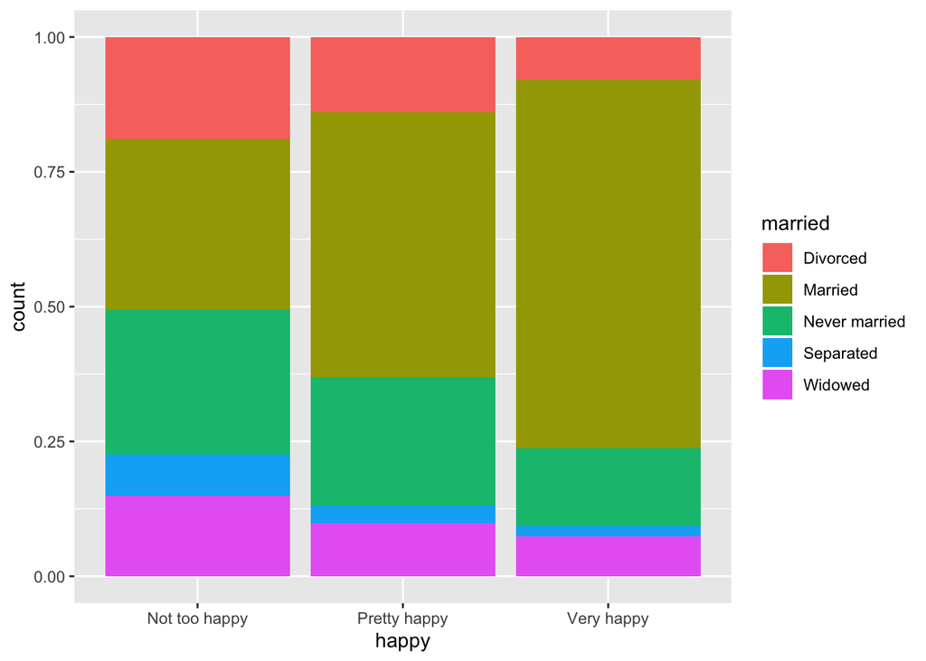

```r
#cleaning a dataset for questions 1 and 2
dat1 <- dat[!(dat$happy =="No answer" | dat$happy =="Not applicable" | dat$happy =="Don't know" | dat$married == "No answer"),]


library(ggplot2)
ggplot(dat1, aes(happy)) + geom_bar(aes(fill = married), position = "fill")
```

Those who were married were the only group that were the majority very happy. The seperated, windowed, and divorced were all majority not too happy, with the never married being split between most of them being not too happy and pretty happy.

2. Does the sex of respondent affect the relationship you found in Q1?

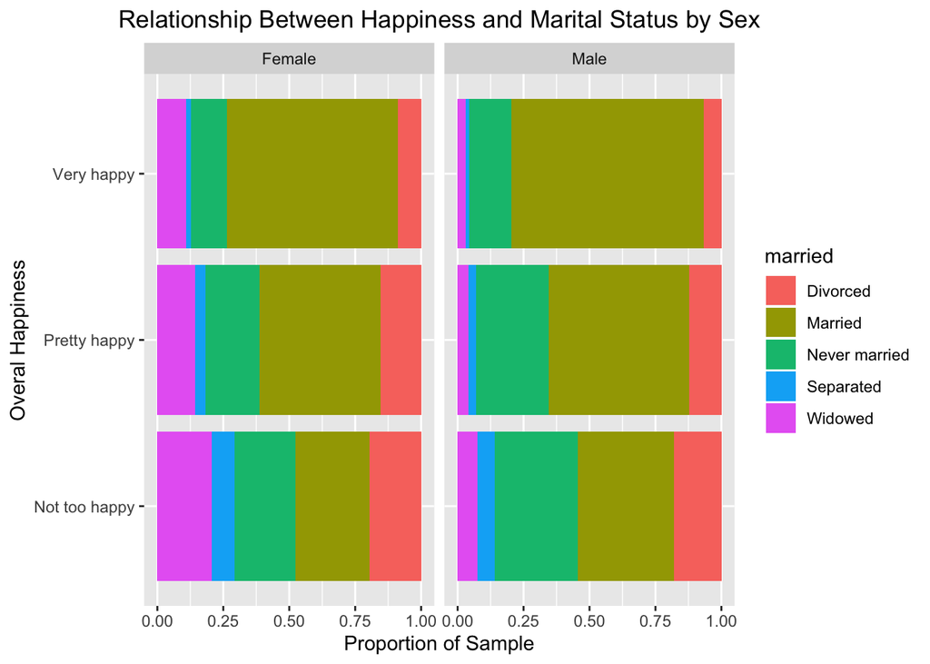

```r
ggplot(dat1, aes(happy)) + geom_bar(aes(fill = married), position = "fill") + facet_wrap(~sex) + coord_flip() + labs(title="Relationship Between Happiness and Marital Status by Sex", x = "Overal Happiness", y = "Proportion of Sample") + theme(plot.title = element_text(hjust = 0.5))
```

Men and women who are “Not too happy” seem to be the same except that there seems to be more unhappiness in men who have never married than women who have never married and there is more unhappinness among women who are widowed than men who are widowed. The “Pretty Happy” bars look very close to the same, there are a smaller number of widowed men who are pretty happy and a larger number of women who are divorced. The “Very Happy” column looks the same, but there are a larger number of men who never married who say they are pretty happy and a much larger number of women who are widowed who say they are very happy.

3. How does the happiness of a respondent relate to the political party affiliation?

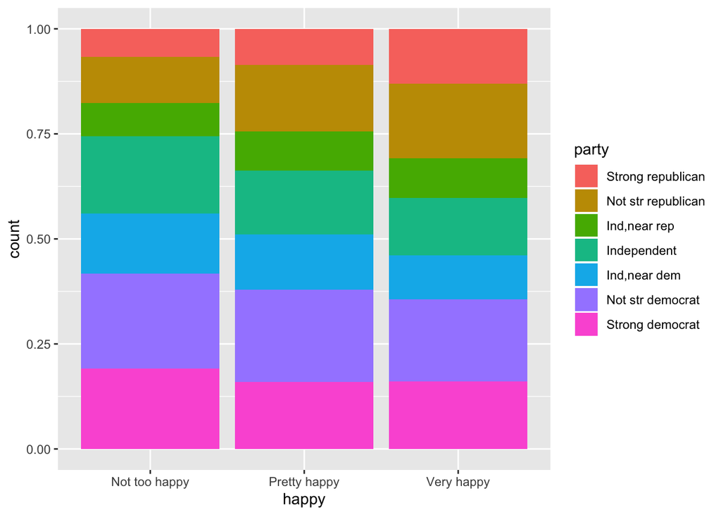

```r
dat4 <- dat[!(dat$happy =="No answer" | dat$happy =="Not applicable" | dat$happy =="Don't know" | dat$party == "Don't know" | dat$party == "No answer" | dat$party == "Other party"),]

dat4$party <- factor(dat4$party, levels = c("Strong republican", "Not str republican", "Ind,near rep","Independent", "Ind,near dem", "Not str democrat","Strong democrat"))


ggplot(dat4, aes(happy)) + geom_bar(aes(fill = party), position = "fill")
```

4. Raise four questions that can be answered by the GSS dataset. Extract appropriate data from the website, explore, and answer the questions.
5. Does religion correlate with happiness? Does the number of children affect this relationship?

```r
dat5 <- select(dat, "children","happy", "relig")
sum(is.na(dat5))
```

```
## [1] 0
```

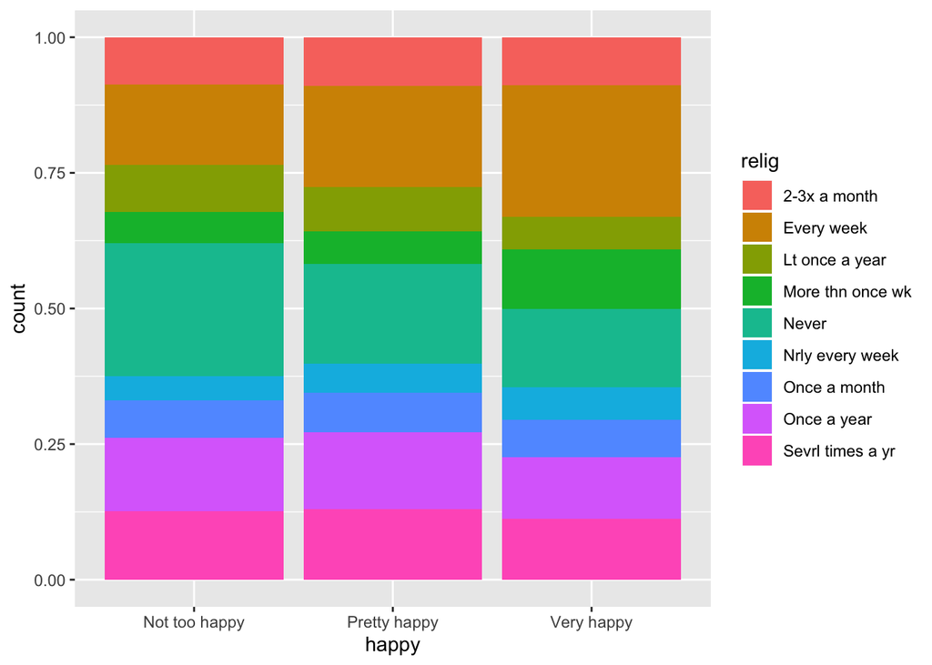

```r
dat5 <- dat5[!(dat5$happy =="No answer" | dat5$happy =="Not applicable" | dat5$happy =="Don't know"),]
dat5 <- dat5[!(dat5$children == "Dk na"),]
dat5 <- dat5[!(dat5$relig == "Dk,na"),]

ggplot(dat5, aes(happy)) + geom_bar(aes(fill = relig), position = "fill")
```

People who attended religious services more frequently tended to be the most happy, while people who went to less religious (or no religious services) were less happy.

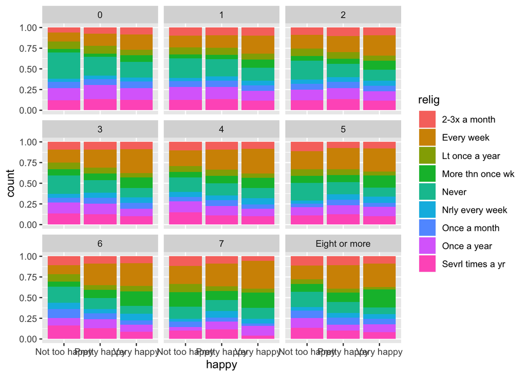

```r
ggplot(dat5, aes(happy)) + geom_bar(aes(fill = relig), position = "fill") + facet_wrap(~children)
```

The relationship appears to be unchanged by number of children of the respondent.

2. Does political affiliation correlate with happiness? Does marital status affect this relationship?

```r
dat2 <- select(dat, 'party','happy','happy_marriage')
sum(is.na(dat2))
```

```
## [1] 0
```

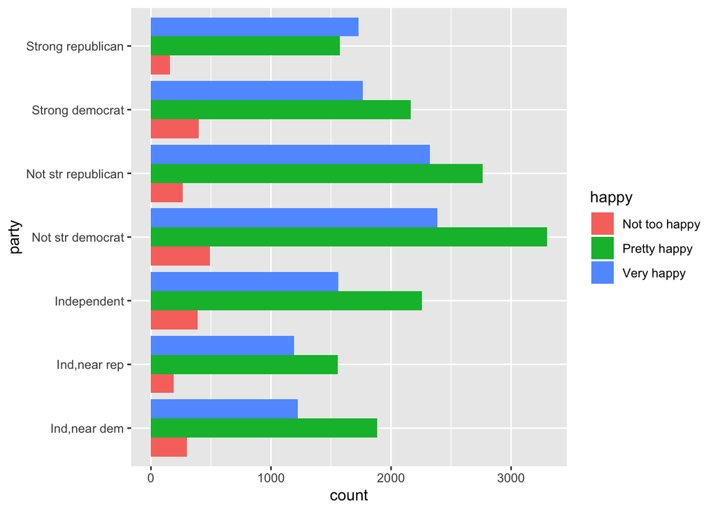

```r
dat2 <- dat2[!(dat2$happy =="No answer" | dat2$happy =="Not applicable" | dat2$happy =="Don't know"),]
dat2 <- dat2[!(dat2$party =="No answer" | dat2$party =="Not applicable" | dat2$party =="Don't know" | dat2$party =="Other party"),]
dat2 <- dat2[!(dat2$happy_marriage =="No answer" | dat2$happy_marriage =="Not applicable" | dat2$happy_marriage =="Don't know"),]


ggplot(dat2,(aes(party))) + geom_bar(aes(fill=happy), position= 'dodge') + coord_flip()
```

It looks like the largest number of pretty or very happy people are the people that are not strongly affiliated with their political party of choice or identify as independent.

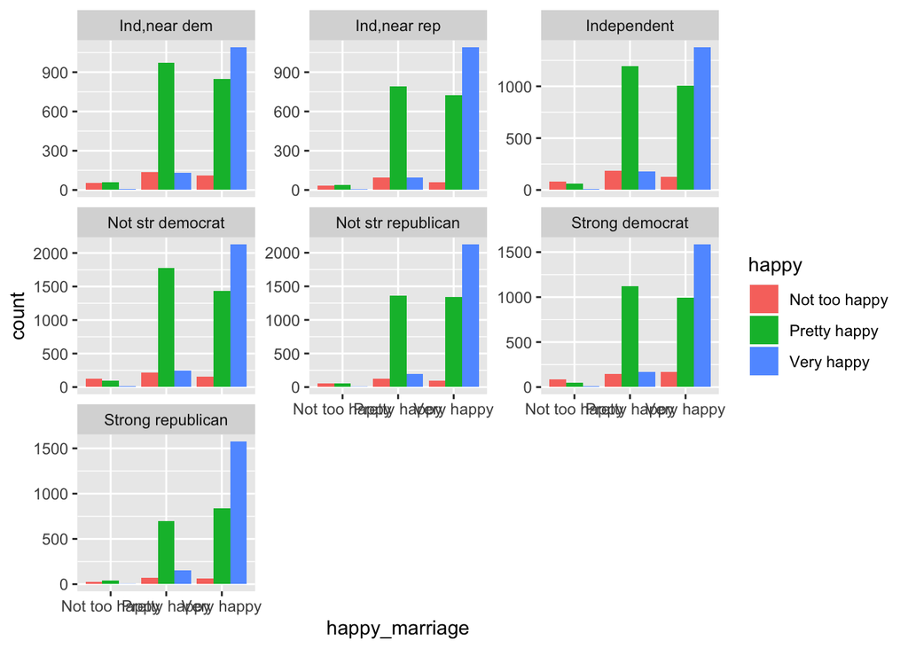

```r
ggplot(dat2,(aes(happy_marriage))) + geom_bar(aes(fill= happy), position= 'dodge')+ facet_wrap(~party, scales = 'free_y')
```

3. Does happiness in marriage correlate with general happiness? How does health and gender effect this relationsihp?

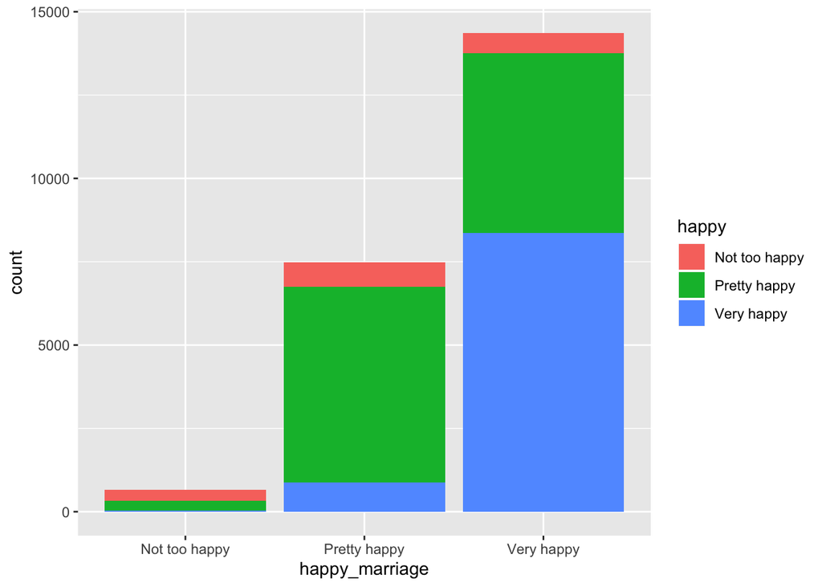

```r
dat3<- select(dat, 'sex','happy','happy_marriage','health')
dat3 <- dat3[!(dat3$happy =="No answer" | dat3$happy =="Not applicable" | dat3$happy =="Don't know"),]
dat3 <- dat3[!(dat3$happy_marriage =="No answer" | dat3$happy_marriage =="Not applicable" | dat3$happy_marriage =="Don't know"),]
dat3 <- dat3[!(dat3$health =="No answer" | dat3$health =="Not applicable" | dat3$health =="Don't know"),]

ggplot(dat3, aes(happy_marriage)) + geom_bar(aes(fill = happy))
```

People who are very happy or pretty happy tend to have very happy or pretty happy marriages.

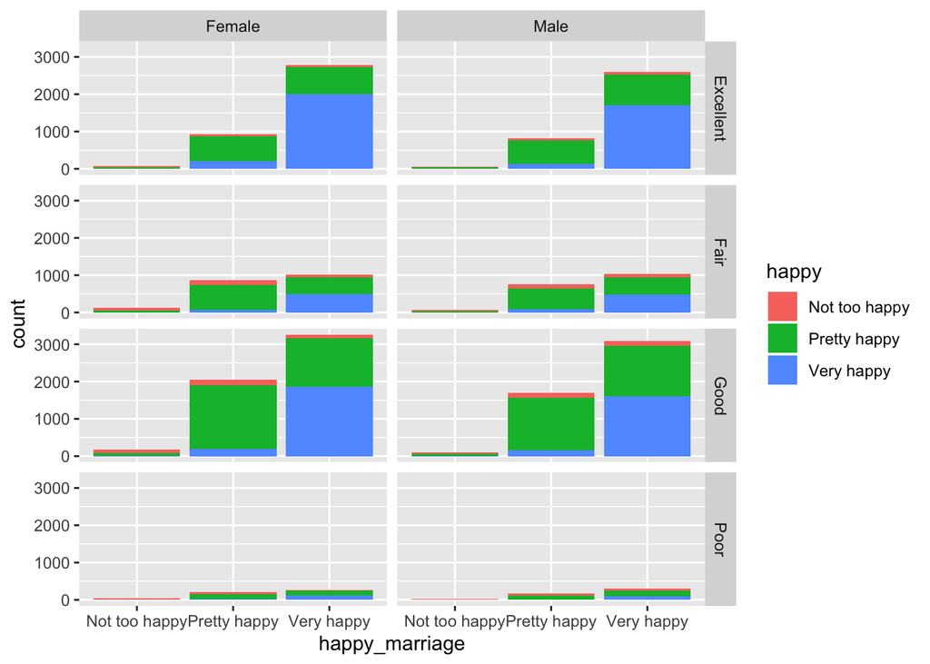

```r
ggplot(dat3, aes(happy_marriage)) + geom_bar(aes(fill = happy))+ facet_grid(health~sex)
```

People who have excellent or good health tend to be happier and have happier marriages. The bars between the sexes look very much the same.

4. How has marital happiness changed over time? Does gender effect this relationship?

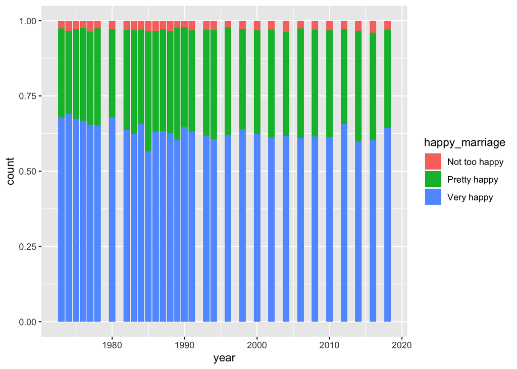

```r
dat6<- select(dat, 'sex','year','happy_marriage')
dat6 <- dat6[!(dat6$happy_marriage =="No answer" | dat6$happy_marriage =="Not applicable" | dat6$happy_marriage =="Don't know"),]


ggplot(dat6, aes(year)) + geom_bar(aes(fill = happy_marriage), position = "fill")
```

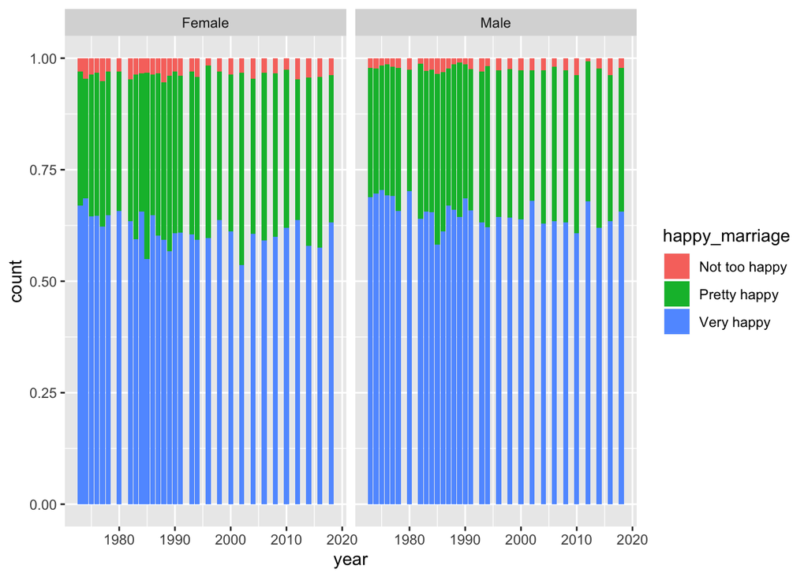

```r
ggplot(dat6, aes(year)) + geom_bar(aes(fill = happy_marriage), position = "fill") + facet_grid(~sex)
```

A larger share of men are very happy compared to women, and less men than women were not too happy, though the trends seem stable over time.